# Midterm Part 2 Options

## Option 1 - Reading a SAM file

In Lab 2, we used `read.table` to import a SAM file. However, typical SAM files can be many gigabytes, and we probably wouldn’t want to read the whole thing at once. Make a function that conserves memory by reading a SAM file in chunks, filtering each chunk and discarding unneeded data before it goes on to the next chunk.

The function should:

- Accept two arguments: a file name, and the name of a chromosome for which to retain alignments.
- Read the file 500 lines at a time, representing 500 sequencing reads.
- Discard header lines starting with “@”
- For each set of 500 reads, only keep reads that align to the indicated chromosome.
- For each set of 500 reads, only keep the first six columns of the file.
- Output a single data frame containing all of the retained information from these six columns.

```r
samChr10 <- readSAM("Lab2_example_align.sam", "Chr10")
head(samChr10)
```

```
##                                       Name Flag Chromosome Position
## 2    D00758:226:HNHHWBCXY:1:1107:1907:2208   16      Chr10 23961160
## 41  D00758:226:HNHHWBCXY:1:1107:11882:2155   16      Chr10   218446
## 105 D00758:226:HNHHWBCXY:1:1107:15413:2451   16      Chr10 60242342
## 241 D00758:226:HNHHWBCXY:1:1107:20150:2639   16      Chr10 21519804
## 280  D00758:226:HNHHWBCXY:1:1107:6084:2899    0      Chr10 16200783
## 355 D00758:226:HNHHWBCXY:1:1107:17795:2789   16      Chr10 24903633
##     Quality CIGAR
## 2         0   92M
## 41        1   92M
## 105      27   79M
## 241      32   92M
## 280       7   91M
## 355      12   92M
```

```r
dim(samChr10)
```

```
## [1] 229   6
```

Hint: `read.table` will give an error if there are zero lines left in the file, so you might choose a different function for reading the chunks, then convert the output to a data frame.

## Option 2 - Interpreting the CIGAR string

For this option, you can skip making a `readSAM` function and read the file the way we did in Lab 2.

```r
samtab <- read.table("Lab2_example_align.sam", sep = "\t", comment.char = "@",
                      stringsAsFactors = FALSE, fill = TRUE)
samtab[[6]][1:50]
```

```
##  [1] "*"           "92M"         "73M"         "92M"         "38M3I50M"
##  [6] "*"           "81M"         "28M4I60M"    "92M"         "92M"
## [11] "34M"         "72M"         "*"           "35M1D53M"    "65M"
## [16] "26M1I65M"    "9M"          "*"           "*"           "10M7D82M"
## [21] "92M"         "*"           "92M"         "92M"         "92M"
## [26] "92M"         "92M"         "92M"         "92M"         "4M4I6M1I77M"
## [31] "*"           "92M"         "92M"         "92M"         "*"
## [36] "*"           "92M"         "*"           "87M"         "92M"
## [41] "92M"         "92M"         "92M"         "52M"         "92M"
## [46] "92M"         "92M"         "92M"         "*"           "92M"
```

Column 6 is a CIGAR string, indicating how the read aligned to the reference. Each value contains a series of numbers, with each number indicating a number of nucleotides in the read, followed by letters. `M` indicates “match”, which in this case means the nucleotide in the reference had a corresponding nucleotide in the read, whether or not they were the same nucleotide. `I` means the read had an insertion with respect to the reference, and `D` indicates the read had a deletion with respect to the reference. So, for example, in `4M4I6M1I77M` there were 4 bases matching to the reference, followed by a 4-base insertion, followed by six bases matching the reference, followed by a one-base insertion, followed by 77 bases matching the reference.

Write a function to return the indices of reads containing a single deletion and no insertions. Have it also return the length of the deletion and the total length of the two flanking matches. (The two vectors can be returned as a data frame, or a list of vectors.) The function can take the column of CIGAR strings as its only argument.

```r
mydel <- findDeletions(samtab[[6]])
dim(mydel)
```

```
## [1] 511   3
```

```r
head(mydel)
```

```
##   Index Deletion_length Match_length
## 1    14               1           88
## 2    20               7           92
## 3    98               4           92
## 4   115              12           92
## 5   118               1           92
## 6   154              10           92
```

```r
head(samtab[[6]][mydel$Index])
```

```
## [1] "35M1D53M"  "10M7D82M"  "33M4D59M"  "56M12D36M" "39M1D53M"  "54M10D38M"
```

## Option 3 - Visualizing the SAM file

For this option, import `samtab` as in option 2, then make a function to visualize it. Say you want to inspect the relationship between read length and alignment quality, and see how this differs between assembled chromosomes and scaffold sequences that have not yet been placed on a chromosome.

- Put the length of the sequence read on the x-axis. This information is not already in the table, but your function can determine the length by looking at the sequence itself.
- Put the quality score on the y-axis. The quality score is the fifth column of the SAM file.
- Make a scatter plot and add some smoothing curves.
- Be sure to filter out any unaligned reads.
- Split the plot into two based on whether the read aligned to a chromosome (“Chr”) or a scaffold (“scaffold”)

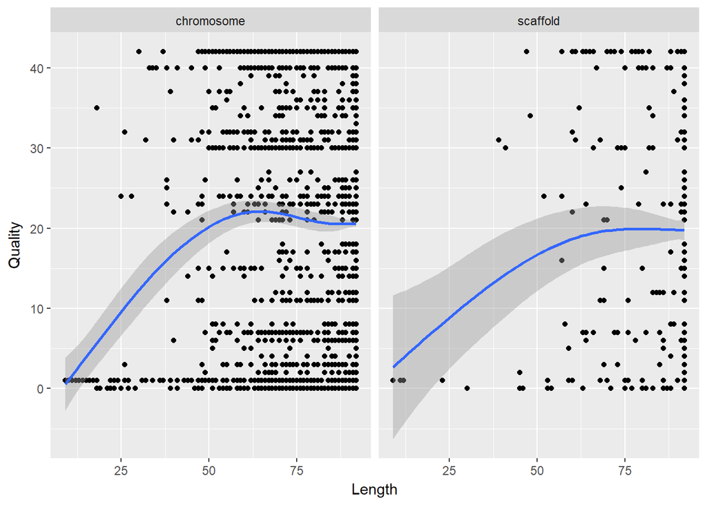

```r
visualizeSAM(samtab)
```